# ML_Shubham_Paliwal_1800076A303_End-Term Submission

## Data Distribution and spread

### Variables Understanding

```python
## Here we're  checking one by one each variable distribution. start with 'Cut'.
df_diamonds['cut'].value_counts()/df_diamonds['cut'].value_counts().sum()*100
```

```
Ideal        39.953652
Premium      25.567297
Very Good    22.398962
Good          9.095291
Fair          2.984798
Name: cut, dtype: float64
```

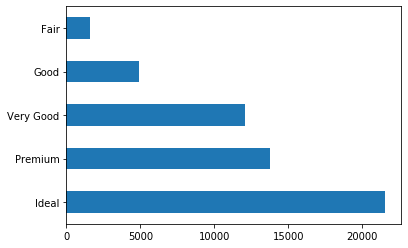

```python
df_diamonds['cut'].value_counts().plot.barh()
```

#### we can see that almost 40% of the data of cut is related to Ideal cut and rest 25 25 under premium & Very Good as per the distribution of the variable we can see that least important is Fair. but still we're not sure yet. let's go ahead...

```python
## Secondly, now we are taking color variable and checking its distribution.
df_diamonds['color'].value_counts()
```

```
G    11292
E     9797
F     9542
H     8304
D     6775
I     5422
J     2808
Name: color, dtype: int64
```

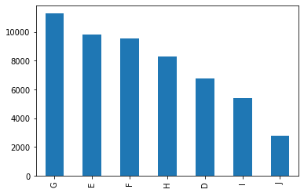

```python
df_diamonds['color'].value_counts().plot.bar()
```

#### Same as previously explained, G - Green color category got the highest weigtage in amount of numbers counting.

```python
## Now we are taking 'Clarity' variable and checking how it is distributed.
df_diamonds['clarity'].value_counts()
```

```
SI1     13065
VS2     12258
SI2      9194
VS1      8171
VVS2     5066
VVS1     3655
IF       1790
I1        741
Name: clarity, dtype: int64
```

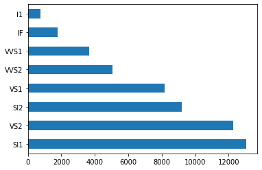

```python
df_diamonds['clarity'].value_counts().plot.barh()
```

#### Again, SI1 is on peak and got highest number of counts

## Basic Visualization:

### Now here we're defining our Target Variable which is "Price", and try to observe its distribution and spread on the normal distributioncurve.

### Target Variable - Price

```python
import seaborn as sns
```

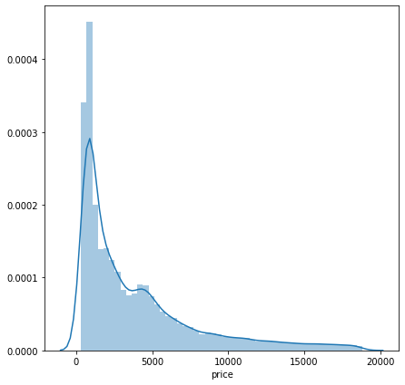

```python
# Setting the plot size
fig, axis = plt.subplots(figsize=(7,7))
# We use kde=True to plot the gaussian kernal density estimate
sns.distplot(df_diamonds['price'], bins=50, kde=True)
```

### Here we need to work on it.

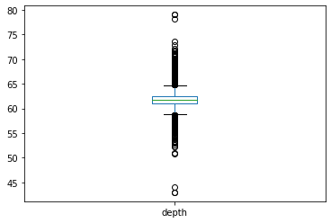

```python
## Continuous variable distribution, start with depth, then table, then carat.
df_diamonds['depth'].plot.box()
```

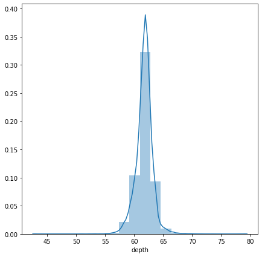

```python
# Setting the plot size
fig, axis = plt.subplots(figsize=(7,7))
# We use kde=True to plot the gaussian kernal density estimate
sns.distplot(df_diamonds['depth'], bins=20, kde=True)
```

#### Depth - range of 55 to 65 cover large amount of data distribution.

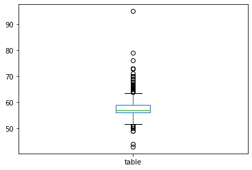

```python
## Table - Distribution
df_diamonds['table'].plot.box()
```

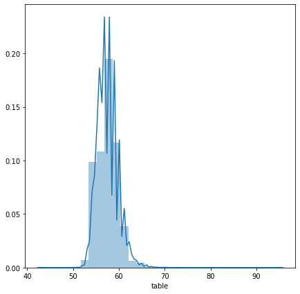

```python
# Setting the plot size
fig, axis = plt.subplots(figsize=(7,7))
# We use kde=True to plot the gaussian kernal density estimate
sns.distplot(df_diamonds['table'], bins=30, kde=True)
```

#### Table - more than 90% of table distribution is under the range of 50 to 70. fair enough, we'll move ahead.

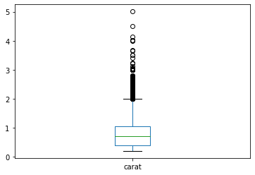

```python
## Now Carat
df_diamonds['carat'].plot.box()
```

### It becomes hard to comment on single values of a variable which is continuous in nature and can having too many values, that too analysing it in uni-variate fashion and commenting on a trend or general behaviour becomes tough. So, here categorising the Price(s) comes to rescue and will help us understand the behaviour of Price in a much convinient way.

```python
# Convert target variable to categorical like low,medium,high and prime price and analyse:

df_diamonds.loc[df_diamonds['price'] <= 5000,'Price_Cat'] = 0
df_diamonds.loc[(df_diamonds['price'] > 5000) & (df_diamonds.price <=10000),'Price_Cat'] = 1
df_diamonds.loc[(df_diamonds['price'] > 10000) & (df_diamonds.price <=15000),'Price_Cat'] = 2
df_diamonds.loc[df_diamonds['price'] > 15000,'Price_Cat'] = 3
df_diamonds.head(5)
```

|  | carat | cut | color | clarity | depth | table | price | x | y | z | Price_Cat |
| --- | --- | --- | --- | --- | --- | --- | --- | --- | --- | --- | --- |
| 0 | 0.23 | Ideal | E | SI2 | 61.5 | 55.0 | 326 | 3.95 | 3.98 | 2.43 | 0.0 |
| 1 | 0.21 | Premium | E | SI1 | 59.8 | 61.0 | 326 | 3.89 | 3.84 | 2.31 | 0.0 |
| 2 | 0.23 | Good | E | VS1 | 56.9 | 65.0 | 327 | 4.05 | 4.07 | 2.31 | 0.0 |
| 3 | 0.29 | Premium | I | VS2 | 62.4 | 58.0 | 334 | 4.20 | 4.23 | 2.63 | 0.0 |
| 4 | 0.31 | Good | J | SI2 | 63.3 | 58.0 | 335 | 4.34 | 4.35 | 2.75 | 0.0 |

### Breakpoints of 5000, 10000, 150000, and above 15000 is considered to be low, mid, high, and prime which is also clearly seen from the above histogram plot of Price.

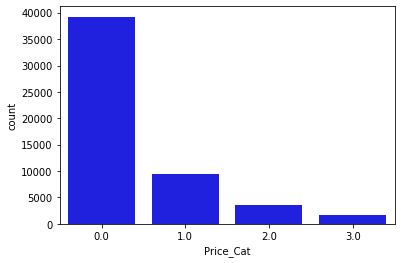

```python
sns.countplot('Price_Cat',data=df_diamonds,color='blue')
plt.show()
```

```python
## checking price effect on 'Cut' variable:
fig, axes = plt.subplots(1,2,figsize=(18,5))
sns.countplot('education',data=df_diamonds,ax=axes[0],color='blue')
sns.countplot('education',hue='Price_Cat',data=df_diamonds,ax=axes[1])
plt.show()
```

[output not shown]

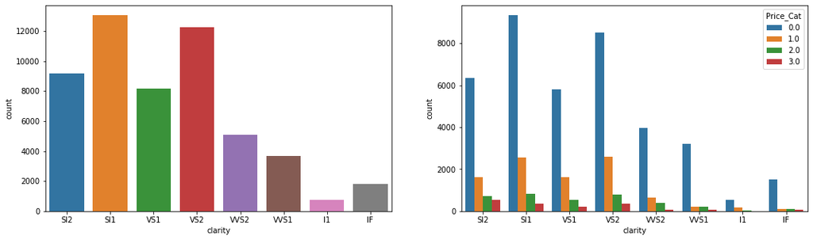

```python
fig, axes = plt.subplots(1,2,figsize=(18,5))
sns.countplot('clarity',data=df_diamonds,ax=axes[0])
sns.countplot('clarity',hue='Price_Cat',data=df_diamonds,ax=axes[1])
plt.show()
```

```python
### Now here we are droping our new variable which was created to see the distribution more precisely "Price-Cat"
df_diamonds.drop('Price_Cat', axis=1, inplace=True)
```

#### Again good enough to checking the distribution of clarity on the basis of price but still not so informative.m

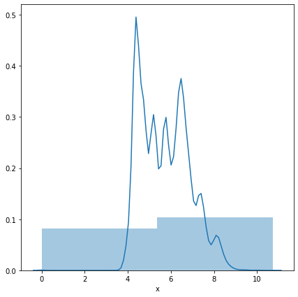

```python
### Checking variable x, whcih is highly spread on the curve
# Setting the plot size
fig, axis = plt.subplots(figsize=(7,7))
# We use kde=True to plot the gaussian kernal density estimate
sns.distplot(df_diamonds['x'], bins=2, kde=True)
```

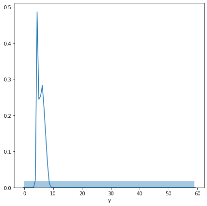

```python
# Setting the plot size
fig, axis = plt.subplots(figsize=(7,7))
# We use kde=True to plot the gaussian kernal density estimate
sns.distplot(df_diamonds['y'], bins=1, kde=True)
```

### Correlation Metrics

```python
# Now, we're tring to see the correlation between the variables and try to check the multicollinearity of the variables.
Correlation = df_diamonds.corr(method='pearson')
Correlation
```

|  | carat | depth | table | price | x | y | z |
| --- | --- | --- | --- | --- | --- | --- | --- |
| carat | 1.000000 | 0.028224 | 0.181618 | 0.921591 | 0.975094 | 0.951722 | 0.953387 |
| depth | 0.028224 | 1.000000 | -0.295779 | -0.010647 | -0.025289 | -0.029341 | 0.094924 |
| table | 0.181618 | -0.295779 | 1.000000 | 0.127134 | 0.195344 | 0.183760 | 0.150929 |
| price | 0.921591 | -0.010647 | 0.127134 | 1.000000 | 0.884435 | 0.865421 | 0.861249 |
| x | 0.975094 | -0.025289 | 0.195344 | 0.884435 | 1.000000 | 0.974701 | 0.970772 |
| y | 0.951722 | -0.029341 | 0.183760 | 0.865421 | 0.974701 | 1.000000 | 0.952006 |
| z | 0.953387 | 0.094924 | 0.150929 | 0.861249 | 0.970772 | 0.952006 | 1.000000 |

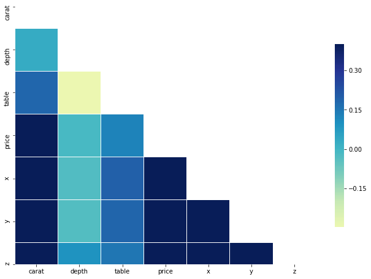

```python
# Generate a mask for the upper trinagle
# np.zeros_like_Return an array of zeros with the same shape
# and type as per given array
# In this case we pass the correlation matrix
# we create a varibale "mask" which is a 14 x 14 numpy array
mask = np.zeros_like(Correlation, dtype=np.bool)

# we create a tuple with triu_indices_from() passing the "mask" array
# k is used to offset diagonal
# with k=0, we offset all diagonal
# if we put k=13, means we offset 14-13=1 diagonal

# triu_indices_from() return the indices for the upper-trinagle of err.
mask[np.triu_indices_from(mask, k=0)]=True

#Setting the plot size
fig, axis = plt.subplots(figsize=(11,11))
# cbar_kwn=("shrink":0.5) is shrinking the legend color bar
sns.heatmap(Correlation, mask=mask, cmap="YlGnBu", vmax=.4, center=0, square=True, linewidths=.1, cbar_kws={"shrink":0.5})
```

```python
links = Correlation.stack().reset_index()
links.columns = ['var1', 'var2','value']
```

```python
links_filtered=links.loc[ (links['value'] > 0.95) & (links['var1'] != links['var2']) ]
links_filtered
```

|  | var1 | var2 | value |
| --- | --- | --- | --- |
| 4 | carat | x | 0.975094 |
| 5 | carat | y | 0.951722 |
| 6 | carat | z | 0.953387 |
| 28 | x | carat | 0.975094 |
| 33 | x | y | 0.974701 |
| 34 | x | z | 0.970772 |
| 35 | y | carat | 0.951722 |
| 39 | y | x | 0.974701 |
| 41 | y | z | 0.952006 |
| 42 | z | carat | 0.953387 |
| 46 | z | x | 0.970772 |
| 47 | z | y | 0.952006 |

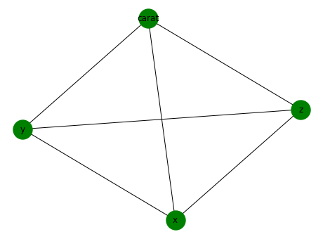

```python
# Creating a network graph to see the correlation
import networkx as nx
G=nx.from_pandas_edgelist(links_filtered, 'var1', 'var2')
plt.subplots(figsize=(8,6))
nx.draw(G, with_labels=True, node_color='green', node_size=500, edge_color='black', linewidths=6, font_size=12)
```

# FUNCTIONS TAB

```python
def set_plot_sizes(sml, med, big):
    plt.rc('font', size=sml)          # controls default text sizes
    plt.rc('axes', titlesize=sml)     # fontsize of the axes title
    plt.rc('axes', labelsize=med)    # fontsize of the x and y labels
    plt.rc('xtick', labelsize=sml)    # fontsize of the tick labels
    plt.rc('ytick', labelsize=sml)    # fontsize of the tick labels
    plt.rc('legend', fontsize=sml)    # legend fontsize
    plt.rc('figure', titlesize=big)  # fontsize of the figure title
def add_datepart(df, fldnames, drop=True, time=False, errors="raise"):
    """add_datepart converts a column of df from a datetime64 to many columns containing
    the information from the date. This applies changes inplace.
    Parameters:
    -----------
    df: A pandas data frame. df gain several new columns.
    fldname: A string or list of strings that is the name of the date column you wish to expand.
        If it is not a datetime64 series, it will be converted to one with pd.to_datetime.
    drop: If true then the original date column will be removed.
    time: If true time features: Hour, Minute, Second will be added.
    Examples:
    ---------
    >>> df = pd.DataFrame({ 'A' : pd.to_datetime(['3/11/2000', '3/12/2000', '3/13/2000'], infer_datetime_format=False) })
    >>> df
        A
    0   2000-03-11
    1   2000-03-12
    2   2000-03-13
    >>> add_datepart(df, 'A')
    >>> df
        AYear AMonth AWeek ADay ADayofweek ADayofyear AIs_month_end AIs_month_start AIs_quarter_end AIs_quarter_start AIs_year_end AIs_year_start AElapsed
    0   2000  3      10    11   5          71         False         False           False           False             False        False          952732800
    1   2000  3      10    12   6          72         False         False           False           False             False        False          952819200
    2   2000  3      11    13   0          73         False         False           False           False             False        False          952905600
    >>>df2 = pd.DataFrame({'start_date' : pd.to_datetime(['3/11/2000','3/13/2000','3/15/2000']),
                            'end_date':pd.to_datetime(['3/17/2000','3/18/2000','4/1/2000'],infer_datetime_format=True)})
    >>>df2
        start_date	end_date
    0	2000-03-11	2000-03-17
    1	2000-03-13	2000-03-18
    2	2000-03-15	2000-04-01
    >>>add_datepart(df2,['start_date','end_date'])
    >>>df2
    	start_Year	start_Month	start_Week	start_Day	start_Dayofweek	start_Dayofyear	start_Is_month_end	start_Is_month_start	start_Is_quarter_end	start_Is_quarter_start	start_Is_year_end	start_Is_year_start	start_Elapsed	end_Year	end_Month	end_Week	end_Day	end_Dayofweek	end_Dayofyear	end_Is_month_end	end_Is_month_start	end_Is_quarter_end	end_Is_quarter_start	end_Is_year_end	end_Is_year_start	end_Elapsed
    0	2000	    3	        10	        11	        5	            71	            False	            False	                False	                False	                False	            False	            952732800	    2000	    3	        11	        17	    4	            77	            False	            False	            False	            False	                False	        False	            953251200
    1	2000	    3	        11	        13	        0	            73	            False	            False	                False	                False               	False           	False           	952905600     	2000       	3	        11      	18  	5           	78          	False	            False           	False           	False               	False          	False           	953337600
    2	2000	    3	        11	        15	        2           	75          	False           	False               	False               	False               	False               False           	953078400      	2000    	4          	13      	1   	5           	92          	False           	True            	False           	True                	False          	False           	954547200
    """
    if isinstance(fldnames,str):
        fldnames = [fldnames]
    for fldname in fldnames:
        fld = df[fldname]
        fld_dtype = fld.dtype
        if isinstance(fld_dtype, pd.core.dtypes.dtypes.DatetimeTZDtype):
            fld_dtype = np.datetime64

        if not np.issubdtype(fld_dtype, np.datetime64):
            df[fldname] = fld = pd.to_datetime(fld, infer_datetime_format=True, errors=errors)
        targ_pre = re.sub('[Dd]ate$', '', fldname)
        attr = ['Year', 'Month', 'Week', 'Day', 'Dayofweek', 'Dayofyear',
                'Is_month_end', 'Is_month_start', 'Is_quarter_end', 'Is_quarter_start', 'Is_year_end', 'Is_year_start']
        if time: attr = attr + ['Hour', 'Minute', 'Second']
        for n in attr: df[targ_pre + n] = getattr(fld.dt, n.lower())
        df[targ_pre + 'Elapsed'] = fld.astype(np.int64) // 10 ** 9
        if drop: df.drop(fldname, axis=1, inplace=True)




def train_cats(df):
    """Change any columns of strings in a panda's dataframe to a column of
    categorical values. This applies the changes inplace.
    Parameters:
    -----------
    df: A pandas dataframe. Any columns of strings will be changed to
        categorical values.
    Examples:
    ---------
    >>> df = pd.DataFrame({'col1' : [1, 2, 3], 'col2' : ['a', 'b', 'a']})
    >>> df
       col1 col2
    0     1    a
    1     2    b
    2     3    a
    note the type of col2 is string
    >>> train_cats(df)
    >>> df
       col1 col2
    0     1    a
    1     2    b
    2     3    a
    now the type of col2 is category
    """
    for n,c in df.items():
        if is_string_dtype(c): df[n] = c.astype('category').cat.as_ordered()

def rf_feat_importance(m, df):
    return pd.DataFrame({'cols':df.columns, 'imp':m.feature_importances_}
                       ).sort_values('imp', ascending=False)



def proc_df(df, y_fld=None, skip_flds=None, ignore_flds=None, do_scale=False, na_dict=None,
            preproc_fn=None, max_n_cat=None, subset=None, mapper=None):

    if not ignore_flds: ignore_flds=[]
    if not skip_flds: skip_flds=[]
    if subset: df = get_sample(df,subset)
    else: df = df.copy()
    ignored_flds = df.loc[:, ignore_flds]
    df.drop(ignore_flds, axis=1, inplace=True)
    if preproc_fn: preproc_fn(df)
    if y_fld is None: y = None
    else:
        if not is_numeric_dtype(df[y_fld]): df[y_fld] = pd.Categorical(df[y_fld]).codes
        y = df[y_fld].values
        skip_flds += [y_fld]
    df.drop(skip_flds, axis=1, inplace=True)

    if na_dict is None: na_dict = {}
    else: na_dict = na_dict.copy()
    na_dict_initial = na_dict.copy()
    for n,c in df.items(): na_dict = fix_missing(df, c, n, na_dict)
    if len(na_dict_initial.keys()) > 0:
        df.drop([a + '_na' for a in list(set(na_dict.keys()) - set(na_dict_initial.keys()))], axis=1, inplace=True)
    if do_scale: mapper = scale_vars(df, mapper)
    for n,c in df.items(): numericalize(df, c, n, max_n_cat)
    df = pd.get_dummies(df, dummy_na=True)
    df = pd.concat([ignored_flds, df], axis=1)
    res = [df, y, na_dict]
    if do_scale: res = res + [mapper]
    return res

def fix_missing(df, col, name, na_dict):

    if is_numeric_dtype(col):
        if pd.isnull(col).sum() or (name in na_dict):
            df[name+'_na'] = pd.isnull(col)
            filler = na_dict[name] if name in na_dict else col.median()
            df[name] = col.fillna(filler)
            na_dict[name] = filler
    return na_dict

def numericalize(df, col, name, max_n_cat):

    if not is_numeric_dtype(col) and ( max_n_cat is None or len(col.cat.categories)>max_n_cat):
        df[name] = pd.Categorical(col).codes+1

def get_sample(df,n):
    """ Gets a random sample of n rows from df, without replacement.
    Parameters:
    -----------
    df: A pandas data frame, that you wish to sample from.
    n: The number of rows you wish to sample.
    Returns:
    --------
    return value: A random sample of n rows of df.
    Examples:
    ---------
    >>> df = pd.DataFrame({'col1' : [1, 2, 3], 'col2' : ['a', 'b', 'a']})
    >>> df
       col1 col2
    0     1    a
    1     2    b
    2     3    a
    >>> get_sample(df, 2)
       col1 col2
    1     2    b
    2     3    a
    """
    idxs = sorted(np.random.permutation(len(df))[:n])
    return df.iloc[idxs].copy()

def draw_tree(t, df, size=10, ratio=0.6, precision=0):
    """ Draws a representation of a random forest in IPython.
    Parameters:
    -----------
    t: The tree you wish to draw
    df: The data used to train the tree. This is used to get the names of the features.
    """
    s=export_graphviz(t, out_file=None, feature_names=df.columns, filled=True,
                      special_characters=True, rotate=True, precision=precision)
    IPython.display.display(graphviz.Source(re.sub('Tree {',
       f'Tree {{ size={size}; ratio={ratio}', s)))

def set_rf_samples(n):
    """ Changes Scikit learn's random forests to give each tree a random sample of
    n random rows.
    """
    forest._generate_sample_indices = (lambda rs, n_samples:
        forest.check_random_state(rs).randint(0, n_samples, n))

def reset_rf_samples():
    """ Undoes the changes produced by set_rf_samples.
    """
    forest._generate_sample_indices = (lambda rs, n_samples:
        forest.check_random_state(rs).randint(0, n_samples, n_samples))

def parallel_trees(m, fn, n_jobs=8):
        return list(ProcessPoolExecutor(n_jobs).map(fn, m.estimators_))
```

## Pre Processing:

```python
df_diamonds.price = np.log(df_diamonds.price)
```

```python
df, y, nas = proc_df(df_diamonds, 'price')
```

```python
m = RandomForestRegressor(n_jobs=-1)
m.fit(df, y)
m.score(df,y)
```

```
0.9984488626085521
```

### We're using random forest regression because our target variable is continous:

### Split data into 80:20 as train and validation sets.

```python
def split_vals(a,n): return a[:n].copy(), a[n:].copy()

n_valid = 10800  # 80:20 as train and validation dataset distribution
n_trn = len(df)-n_valid
raw_train, raw_valid = split_vals(df_diamonds, n_trn)
X_train, X_valid = split_vals(df, n_trn)
y_train, y_valid = split_vals(y, n_trn)

X_train.shape, y_train.shape, X_valid.shape
```

```
((43140, 9), (43140,), (10800, 9))
```

## Base model - Let's try our model again, this time with separate training and validation sets.

```python
def rmse(x,y): return math.sqrt(((x-y)**2).mean())

def print_score(m):
    res = [rmse(m.predict(X_train), y_train), rmse(m.predict(X_valid), y_valid),
                m.score(X_train, y_train), m.score(X_valid, y_valid)]
    if hasattr(m, 'oob_score_'): res.append(m.oob_score_)
    print(res)
```

```python
m = RandomForestRegressor(n_jobs=-1)
%time m.fit(X_train, y_train)
print_score(m)
```

```
Wall time: 1.12 s
[0.038315628989959924, 0.25030186581073527, 0.9987811063634944, 0.6865854041069801]
```

```python
M = RandomForestRegressor(n_estimators=40, min_samples_leaf=3, max_features=0.5, n_jobs=-1, oob_score=True)
M.fit(X_train, y_train)
print_score(M)
```

```
[0.06206229033478484, 0.22323980535529103, 0.9968020660589991, 0.7506930908926432, 0.992498076929338]
```

```python
fi = rf_feat_importance(m, df); fi[:10]
```

|  | cols | imp |
| --- | --- | --- |
| 7 | y | 0.829135 |
| 0 | carat | 0.115479 |
| 3 | clarity | 0.027700 |
| 6 | x | 0.011718 |
| 2 | color | 0.011557 |
| 8 | z | 0.001505 |
| 4 | depth | 0.001248 |
| 5 | table | 0.000956 |
| 1 | cut | 0.000703 |

## here now we come to the important information which is feature importance and we can see that Y is having highest weightage with .82 followed by carat which is 0.11.

### Let's plot it.

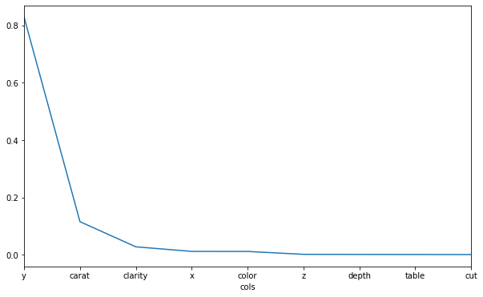

```python
fi.plot('cols', 'imp', figsize=(10,6), legend=False);
```

```python
def plot_fi(fi): return fi.plot('cols', 'imp', 'barh', figsize=(12,7), legend=False)
```

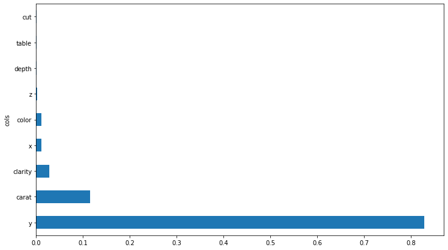

```python
plot_fi(fi[:20]);
```

```python
### here we are keeping feature importance more than .005 and then check what our distrubtion says !!!
to_keep = fi[fi.imp>0.005].cols; len(to_keep)
```

```
5
```

```python
## Now we're keeping only these 5 variables into account for our next Random forest model.
df_keep = df[to_keep].copy()
X_train, X_valid = split_vals(df_keep, n_trn)
```

```python
m = RandomForestRegressor(n_estimators=40, min_samples_leaf=3, max_features=0.5,
                          n_jobs=-1, oob_score=True)
m.fit(X_train, y_train)
print_score(m)
```

```
[0.07275251373467036, 0.22895081390717564, 0.9956054956545884, 0.7377741948610022, 0.9918879211755988]
```

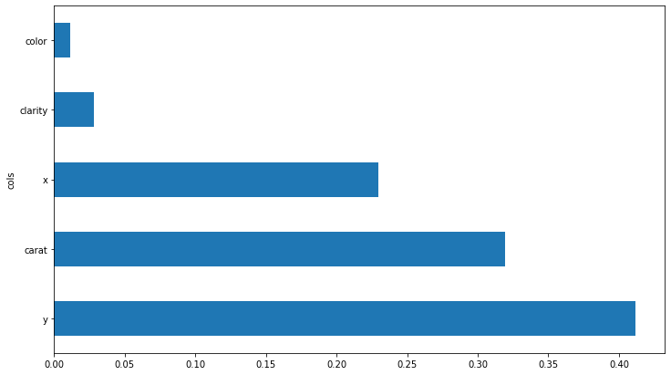

```python
fi = rf_feat_importance(m, df_keep)
plot_fi(fi);
```

## Interesting observation in variable X and Clarity , previously where x is less important than clarity now it get more importance and in carat too previously it was soo far from y now it is quite close to Y.

### Removing redundant features¶

### One thing that makes this harder to interpret is that there seem to be some variables with very similar meanings. Let's try to remove redundent features.

```python
import scipy
from scipy.cluster import hierarchy as hc
```

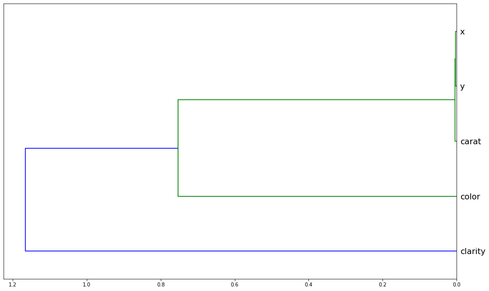

```python
corr = np.round(scipy.stats.spearmanr(df_keep).correlation, 4)
corr_condensed = hc.distance.squareform(1-corr)
z = hc.linkage(corr_condensed, method='average')
fig = plt.figure(figsize=(16,10))
dendrogram = hc.dendrogram(z, labels=df_keep.columns, orientation='left', leaf_font_size=16)
plt.show()
```

```python
S = RandomForestRegressor(n_jobs=-1, random_state=75, n_estimators=80, min_samples_leaf=2,
                          max_features='auto')
%time S.fit(X_train, y_train)
print_score(S)
```

```
Wall time: 3.64 s
[0.05487465499194989, 0.24261867921929417, 0.9974998993295074, 0.7055310468901015]
```

```python
P = RandomForestRegressor(n_jobs=-1, random_state=75, n_estimators=80, min_samples_leaf=4, max_features='auto')
%time P.fit(X_train, y_train)
print_score(P)
```

```
Wall time: 2.98 s
[0.07051263712181746, 0.24128139455378983, 0.9958719228466504, 0.7087682548304384]
```

```python
Q = RandomForestRegressor(n_jobs=-1, random_state=75, n_estimators=75, min_samples_leaf=3, max_features=.75)
Q.fit(X_train, y_train)
print_score(Q)
```

```
[0.06720161988725878, 0.23133940094710112, 0.996250499855709, 0.732274180061852]
```

```python
from sklearn.ensemble import ExtraTreesClassifier, ExtraTreesRegressor
```

```python
M = ExtraTreesRegressor(n_jobs=-1, random_state=75, n_estimators=75, min_samples_leaf=3, max_features=.75)
M.fit(X_train, y_train)
print_score(M)
```

```
[0.07744950273596958, 0.1911746992032337, 0.9950197498354786, 0.8171681410031305]
```

### Here we can see that this is the best optimal point at which RMSE is .1911 and accuracy of validation dataset is 81.71%.

```python
M.score(X_valid, y_valid)
```

```
0.8171681410031305
```

```python
results = pd.DataFrame({'Models by Shubham': ['RandomForestRegressor-S', 'RandomForestRegressor-P', 'RandomForestRegressor-Q','ExtraTreeRegressor'],
                        'Score': [S.score(X_valid, y_valid), P.score(X_valid, y_valid), Q.score(X_valid, y_valid),
                                  M.score(X_valid, y_valid)]})
result_df = results.sort_values(by='Score', ascending=False)
result_df = result_df.set_index('Score')
result_df
```

| Score | Models by Shubham |
| --- | --- |
| 0.817168 | ExtraTreeRegressor |
| 0.732274 | RandomForestRegressor-Q |
| 0.708768 | RandomForestRegressor-P |
| 0.705531 | RandomForestRegressor-S |

### However, we have also considered ExtraTrees Regressor model for the same, where no of trees = 75, min samples leaf = 3 and max features used = .75, we can see the highest accuracy of 81.71% in validation dataset.